# funFunctions

sbsambado

2/8/2021

This script was adapted from [Tanya Rogers](https://outsidethequadrat.weebly.com/), who adapted it from Umi Hoshijima, who adapted it from [Software Carpentry](https://swcarpentry.github.io/r-novice-inflammation/02-func-R/index.html)!

# 1. What do functions do?

**Functions** allow you to ‘do’ things in R. The basic structure of a function is always a term with parentheses, and your inputs go in those parentheses as **arguments**. For example:

- `mean()` is a function that lets you **take the mean** of the input.

```r
# making some data
dat <- c(3, 5, 6, 9)

mean(dat)
```

```
## [1] 5.75
```

- `plot()` is a function that allows you to **make a plot**, and the arguments lets you customize that plot.

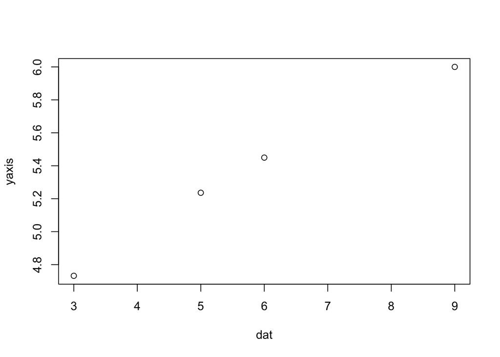

```r
# making some fake data to put into the plot
yaxis <- sqrt(dat) + 3

plot(x = dat, y = yaxis)
```

# 2. Writing your own functions

Sometimes R doesn’t have the function you want. That’s ok, because you can write your own! The function called `function()` lets you write a function. The basic structure is:

function.name <- function(arguments) {  
some operations here using those arguments  
return(output of those operations)  
}

Let’s put that into practice by writing a function to convert temperature values!

The US uses fahrenheit, bleh. Let’s convert that into celsius. The formula for converting fahrenheit into celsius is:

$C = \frac{F-32}{1.8}$

And the formula for converting celsius into fahrenheit is:

$F = C*1.8 + 32$

We can write a function called `f_to_c` that converts fahrenheit to celsius.

```r
f_to_c <- function(x) {
  convert <- (x - 32)/1.8
  return(convert)
}
```

Yay! Now, we can see what 78 fahrenheit is in celsius.

```r
f_to_c(78)
```

```
## [1] 25.55556
```

## Formatting note

The curly brackets in functions are really important for making sure the function code actually works. You can save yourself a headache when you’re writing a function if you immediately hit enter a bunch of times after opening up your brackets. After you’re done writing your function, you can delete all the extraneous space. This ensures that you’re not accidentally deleting your brackets!

Try writing a function called `c_to_f` that converts celsius to fahrenheit! Remember, the formula is:

$C*1.8 + 32 = F$

And check to see if it works!

## A bit fancier

Let’s say that we want to convert between celsius and fahrenheit, but we don’t want to have two separate functions for each. We can write a function with more than one argument and incorporate `if()` statements in order to be able to do that.

In order to wrap our heads around this, let’s think of the functions we just wrote, `f_to_c()` and `c_to_f()`. We can put all of the components of those functions into one, and designate arguments for switching between each conversion. It’s like compressing a bunch of different operations (the conversion) into one thing (the function), and calling the right conversion every time you wanted to use the function (by using the arguments).

Here, we’ll use the `function()` structure to make a function called `temp.conv` that converts between celsius and fahrenheit. Inside the function, we’ll use `if()` statements to switch between all those conversion equations. The `if()` statement allows us to say:  
- **If** the inputs are celsius and fahrenheit, then use this conversion: $x*1.8 +32$.  
- **If** the inputs are fahrenheit and celsius, then use this conversion: $\frac{x-32}{1.8}$.

```r
             # arguments in: from, to, and the temperature
temp.conv <- function(from, to, x) {

  # if `from` is "celsius" and `to` is "fahrenheit", then
  if(from == "celsius" & to == "fahrenheit") {
    # convert from celsius to fahrenheit
    convert <- x*1.8 + 32
  }

  # if `from` is "fahrenheit" and `to` is "celsius", then
  if(from == "fahrenheit" & to == "celsius") {
    # convert from fahrenheit to celsius
    convert <- (x - 32)/1.8
  }

  # return the converted value
  return(convert)
}
```

Let’s try it out! I’ll try converting 25 degrees celsius into fahrenheit.

```r
temp.conv("celsius", "fahrenheit", 25)
```

```
## [1] 77
```

Try it out below!

If you want to incorporate different types of arguments into your function, you can use the or operator: `||`

```r
             # arguments in: from, to, and the temperature
temp.conv <- function(from, to, x) {

  # if `from` is "celsius" or "c", and `to` is "fahrenheit" or "f", then
  if(from == "celsius" || from == "c" & to == "fahrenheit" || to == "f") {
    # convert from celsius to fahrenheit
    convert <- x*1.8 + 32
  }

  # if `from` is "fahrenheit" or "f", and `to` is "celsius" or "c", then
  if(from == "fahrenheit" || from == "f" & to == "celsius" || to == "c") {
    # convert from fahrenheit to celsius
    convert <- (x - 32)/1.8
  }

  # return the converted value
  return(convert)
}
```

Try using the function with the new arguments!